# TARASPINA VP | 16S miTags | Bacteria

Dataset: mapping_SILVA_plus_PhytoRef_plus_CyanoDB_NR99.txt

27.01.2015

# 1) Data overview

Samples with less than 167 reads are removed:

```
## [1] 44069   273
```

```
##       MP0310 MP0311 MP0317 MP0319 MP0320
## OTU_1      0      0      4      3      0
## OTU_2      0      0      5      1      0
## OTU_3      0      0      3      0      0
## OTU_4      0      1     21      6      0
## OTU_5      0      1      8      5      0
```

```
## named numeric(0)
```

```
## named numeric(0)
```

Table dimensions and content outline:

```
## [1] 44069   220
```

```
##       MP0310 MP0311 MP0319 MP0321 MP0323
## OTU_1      0      0      3      1      0
## OTU_2      0      0      1      0      0
## OTU_3      0      0      0      0      0
## OTU_4      0      1      6      8      0
## OTU_5      0      1      5      3      0
```

Minimum number of reads per station:

```r
min(colSums(tp_vp_16SmiTags_b_v2))
```

```
## [1] 997
```

Maximum number of reads per station:

```r
max(colSums(tp_vp_16SmiTags_b_v2))
```

```
## [1] 160614
```

Identification of station with higher number of reads:

```r
amplicons_per_sample_tp_vp_16SmiTags_c<-colSums(tp_vp_16SmiTags_b_v2)
amplicons_per_sample_tp_vp_16SmiTags_c[which(colSums(tp_vp_16SmiTags_b_v2)>160000)]
```

```
## X93_DCM_0d2.3
##        160614
```

Overall reads per sample:

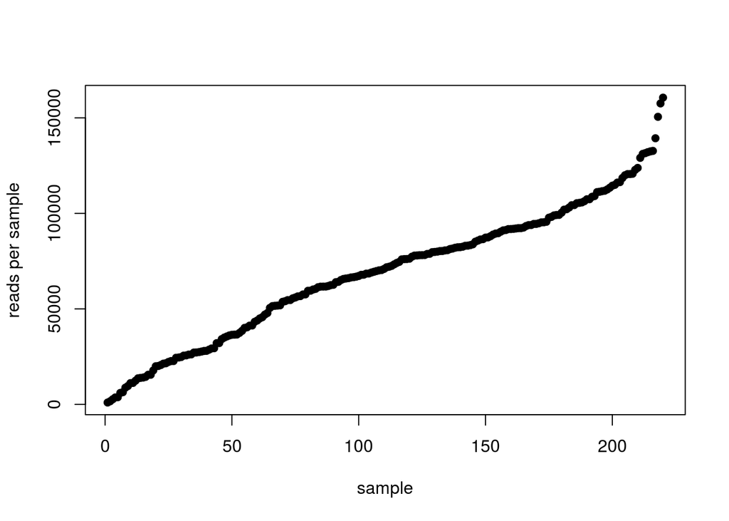

# 2) Normalization to 167 reads per sample

Let’s normalize the original dataset by randomly subsampling 167 reads in each station:

```r
library(vegan)
tp_vp_16SmiTags_b_v2_t<-t(tp_vp_16SmiTags_b_v2)
tp_16mt_b_ss167<-rrarefy(tp_vp_16SmiTags_b_v2_t, 167)
```

The normalized table shows the following dimensions and format:

```
## [1]   220 44069
```

```
##        OTU_1 OTU_2 OTU_3 OTU_4 OTU_5
## MP0310     0     0     0     0     0
## MP0311     0     0     0     0     0
## MP0319     0     0     0     0     0
## MP0321     0     0     0     0     0
## MP0323     0     0     0     0     0
```

Its content fits with the expected normalization values (167 reads per station):

```r
rowSums(tp_16mt_b_ss167)
```

```
##            MP0310            MP0311            MP0319            MP0321
##               167               167               167               167
##            MP0323            MP0528            MP0778            MP0786
##               167               167               167               167
##            MP0888            MP1104            MP1174            MP1176
##               167               167               167               167
##            MP1387            MP1417            MP1421            MP1455
##               167               167               167               167
##            MP1517            MP1527            MP1529            MP1671
##               167               167               167               167
##            MP1672            MP1680            MP1683            MP1684
##               167               167               167               167
##            MP1855            MP1857            MP2239            MP2241
##               167               167               167               167
##            MP2243            MP2376            MP2813            MP2815
##               167               167               167               167
##            MP2819            MP2821             MP581             MP860
##               167               167               167               167
##    X100_DCM_0d2.3    X100_MES_0d2.3    X100_SUR_0d2.3    X102_DCM_0d2.3
##               167               167               167               167
##    X102_MES_0d2.3    X102_SUR_0d2.3    X109_DCM_0d2.3    X109_MES_0d2.3
##               167               167               167               167
##    X109_SUR_0d2.3    X110_DCM_0d2.3    X110_MES_0d2.3    X110_SUR_0d2.3
##               167               167               167               167
##    X111_DCM_0d2.3    X111_MES_0d2.3    X111_SUR_0d2.3    X112_DCM_0d2.3
##               167               167               167               167
##    X112_MES_0d2.3    X112_SUR_0d2.3  X122_DCM_0d1.0d2 X122_DCM_0d2.0d45
##               167               167               167               167
##    X122_DCM_0d2.3 X122_DCM_0d45.0d8  X122_MES_0d1.0d2 X122_MES_0d2.0d45
##               167               167               167               167
##    X122_MES_0d2.3 X122_MES_0d45.0d8  X122_SUR_0d1.0d2 X122_SUR_0d2.0d45
##               167               167               167               167
##    X122_SUR_0d2.3 X122_SUR_0d45.0d8 X123_DCM_0d2.0d45    X123_DCM_0d2.3
##               167               167               167               167
## X123_DCM_0d45.0d8 X123_SUR_0d2.0d45    X123_SUR_0d2.3 X123_SUR_0d45.0d8
##               167               167               167               167
##  X124_DCM_0d1.0d2    X124_DCM_0d2.3 X124_DCM_0d45.0d8  X124_SUR_0d1.0d2
##               167               167               167               167
##    X124_SUR_0d2.3 X124_SUR_0d45.0d8 X125_DCM_0d2.0d45    X125_DCM_0d2.3
##               167               167               167               167
```

[output cut: 55 more lines]

```
##               167               167               167               167
##  X76_MES_0d45.0d8  X76_SUR_0d2.0d45     X76_SUR_0d2.3  X76_SUR_0d45.0d8
##               167               167               167               167
##  X78_DCM_0d2.0d45     X78_DCM_0d2.3  X78_DCM_0d45.0d8     X78_MES_0d2.3
##               167               167               167               167
##  X78_MES_0d45.0d8  X78_SUR_0d2.0d45     X78_SUR_0d2.3  X78_SUR_0d45.0d8
##               167               167               167               167
##    X7_DCM_0d2.1d6     X82_DCM_0d2.3     X82_SUR_0d2.3     X84_SUR_0d2.3
##               167               167               167               167
##     X85_DCM_0d2.3     X85_MES_0d2.3     X85_SUR_0d2.3     X93_DCM_0d2.3
##               167               167               167               167
##     X94_SUR_0d2.3     X96_SUR_0d2.3     X98_DCM_0d2.3     X98_MES_0d2.3
##               167               167               167               167
##     X98_SUR_0d2.3     X99_SUR_0d2.3    X9_DCM_0d2.1d6    X9_SUR_0d2.1d6
##               167               167               167               167
```

Let’s check out how many OTUs don’t appear in the new table:

```r
length(which(colSums(tp_16mt_b_ss167)==0))
```

```
## [1] 37653
```

There are 37653 OTUs that don’t show any occurrence in the normalized data. Let’s remove them from the table and take a look at its final dimensions:

```r
tp_16mt_b_ss167_no_cero<-tp_16mt_b_ss167[,-(which(colSums(tp_16mt_b_ss167)==0))]
dim(tp_16mt_b_ss167_no_cero)
```

```
## [1]  220 6416
```

Datasets summary:

tp_vp_16SmiTags_b_v2_t –> 220 44069

tp_16mt_b_ss167_no_cero –> 220 6416

# 3) General community analysis

## 3.1) Richness and evenness (Shannon index)

Most of the samples take Shannon Index values between 4.7 and 4.9:

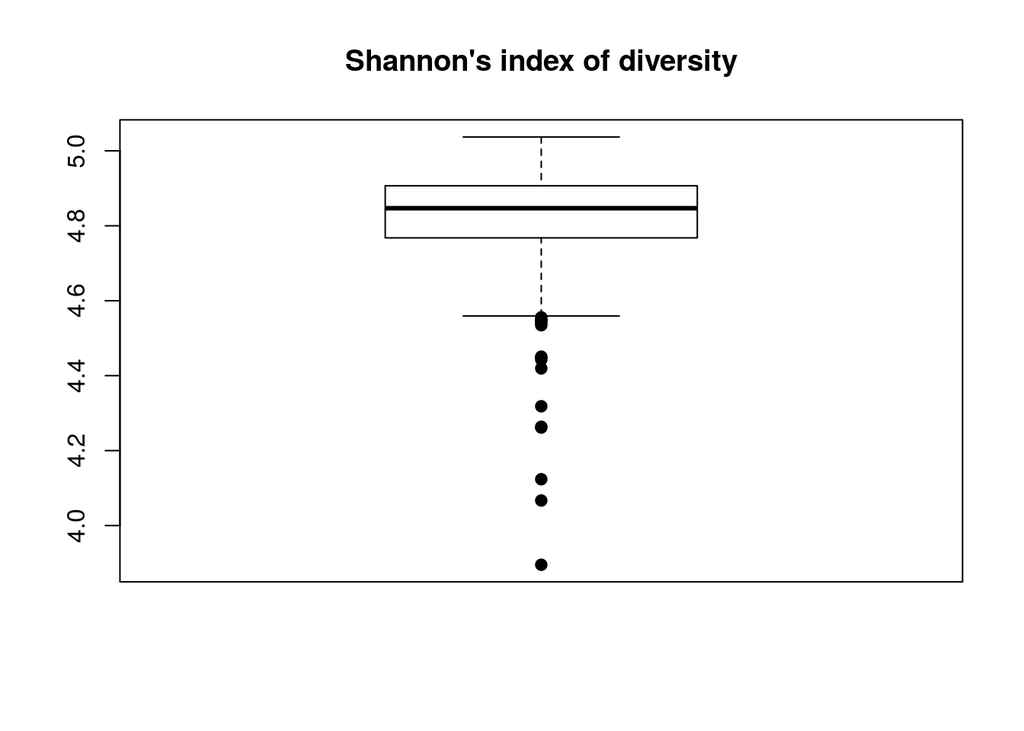

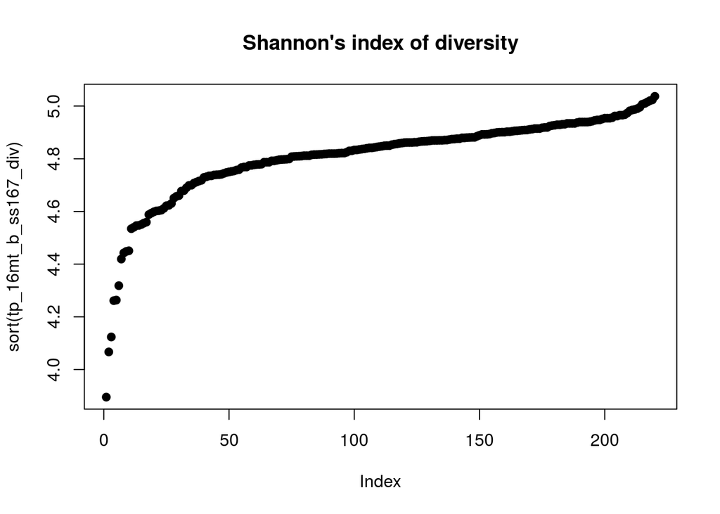

## 3.2) Richness: OTU number

Lowest number of OTUs per sample:

```
## [1] 79
```

Maximum number of OTUs per sample:

```
## [1] 158
```

In most of the samples, we can identify between 130 and 145 OTUs:

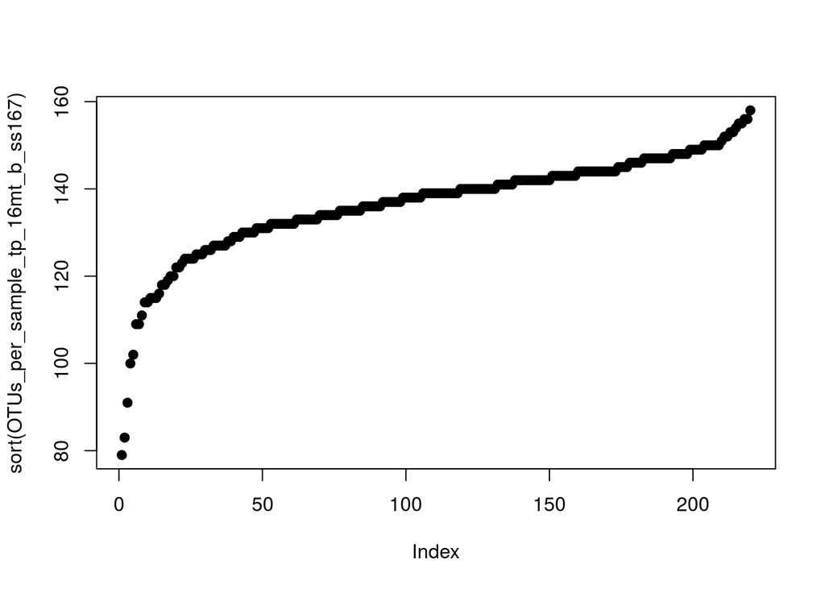

```r
plot(sort(OTUs_per_sample_tp_16mt_b_ss167), pch=19)
```

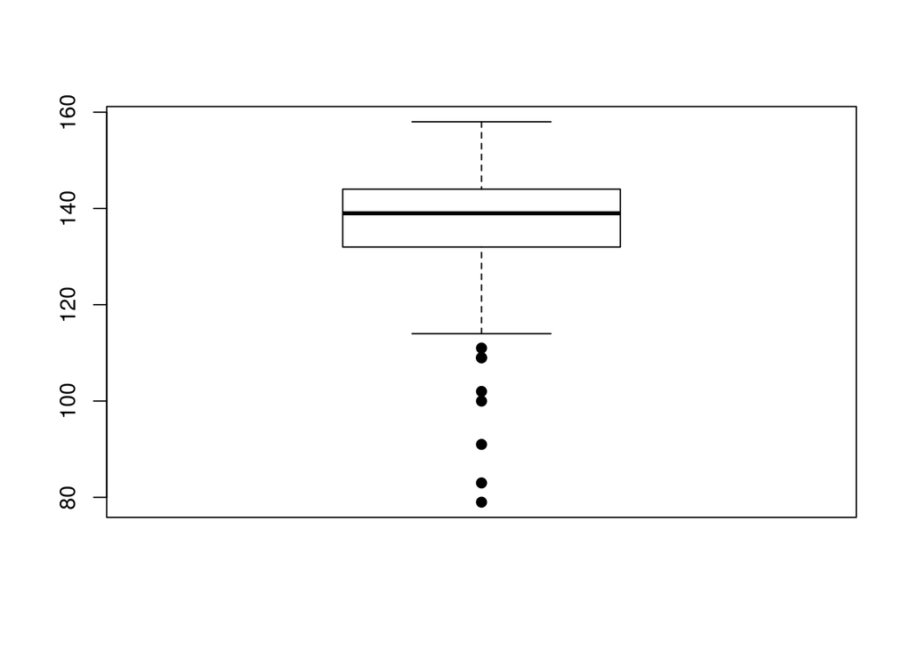

```r
boxplot(OTUs_per_sample_tp_16mt_b_ss167, pch=19)
```

## 3.3) Index of evenness

### 3.3.1) Pielou’s index

```r
pielou_b_venness_tp_16mt_b_ss167 <- tp_16mt_b_ss167_div/log(OTUs_per_sample_tp_16mt_b_ss167)
```

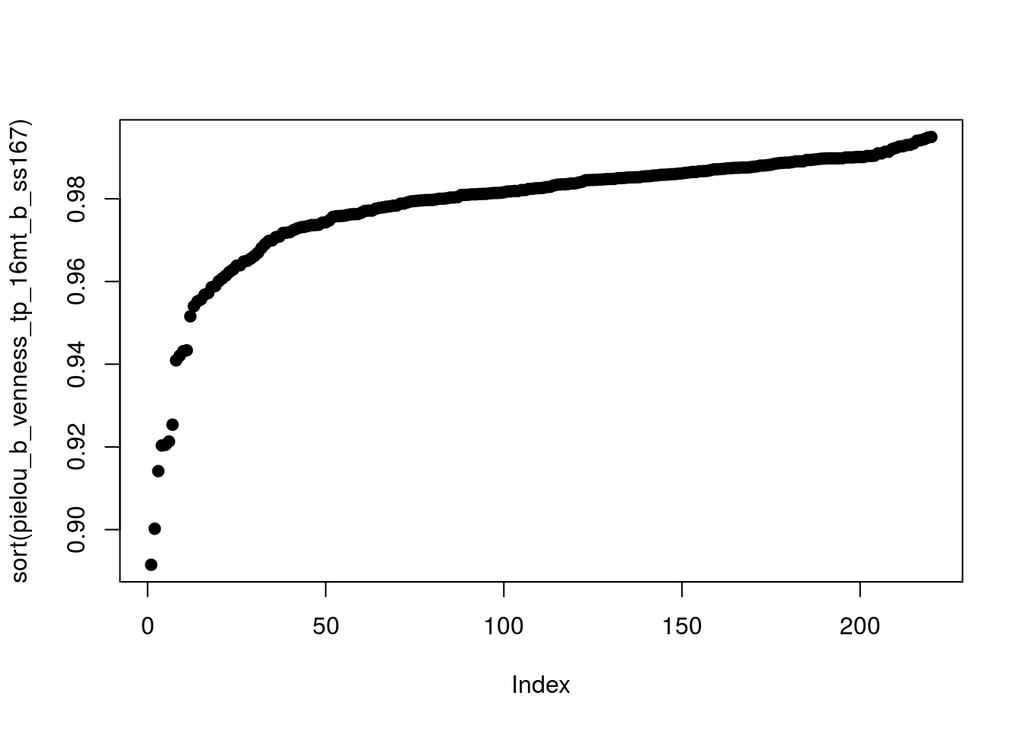

```r
plot(sort(pielou_b_venness_tp_16mt_b_ss167), pch=19)
```

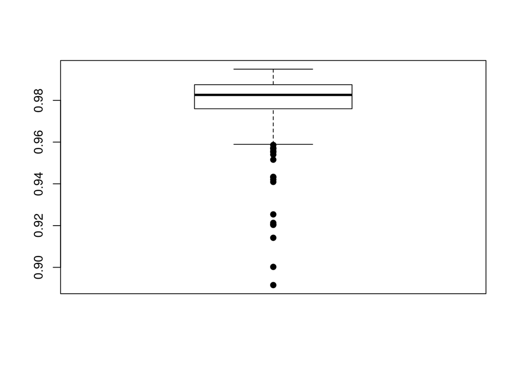

```r
boxplot(pielou_b_venness_tp_16mt_b_ss167, pch=19)
```

The OTU_3009, with 413 reads, is the most abundant in the overall dataset:

```r
head(sort(colSums(tp_16mt_b_ss167_no_cero), decreasing=T), n=10L)
```

```
## OTU_3009  OTU_321 OTU_2241 OTU_1499  OTU_181 OTU_2660  OTU_836 OTU_5223
##      413      340      308      225      224      224      198      177
##  OTU_145  OTU_856
##      145      144
```

Most of the OTUs show few occurrences:

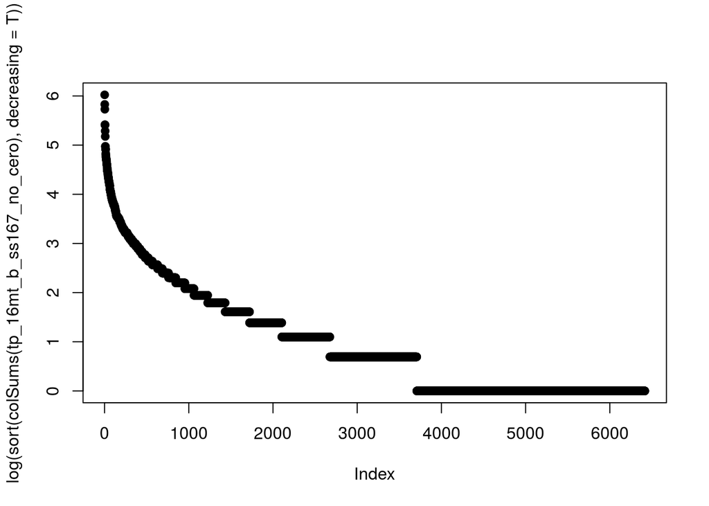

```r
plot(log(sort(colSums(tp_16mt_b_ss167_no_cero), decreasing=T)), pch=19)
```

## 3.4) Abundance Models

### 3.4.2) Preston’s Lognormal Model

According to Preston’s lognormal model fit into species frequencies groups, we’re missing ~80813 species:

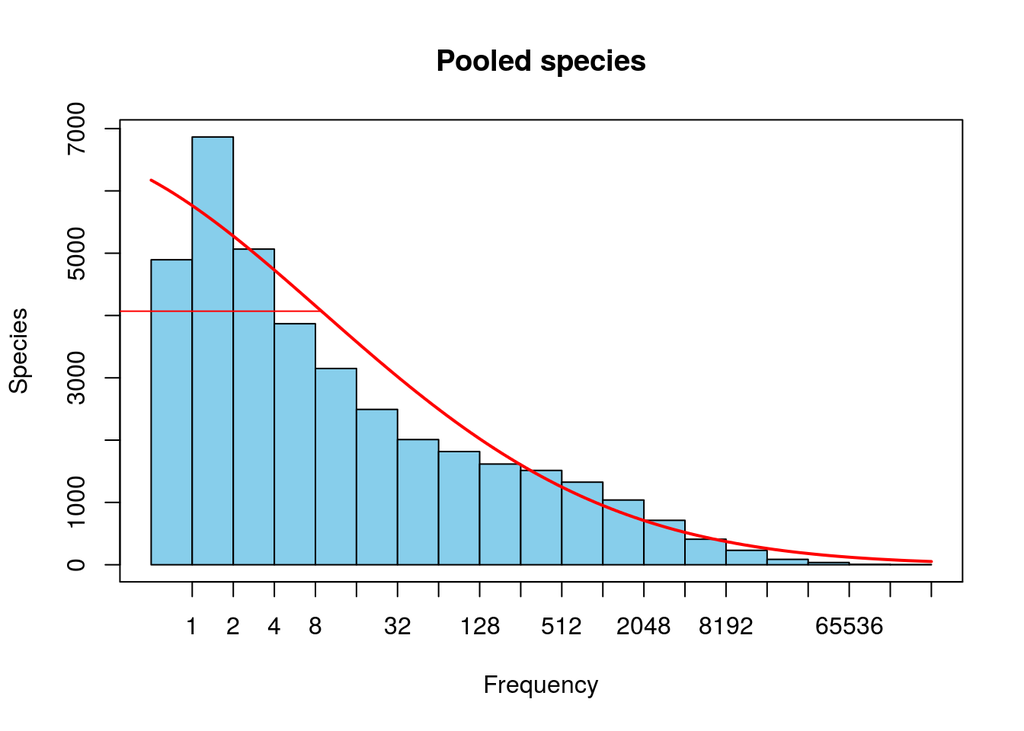

```r
tp_16mt_b_ss167_prestonfit<-prestonfit(colSums(tp_vp_16SmiTags_b_v2_t))
plot(tp_16mt_b_ss167_prestonfit, main="Pooled species")
```

```r
veiledspec(tp_16mt_b_ss167_prestonfit)
```

```
## Extrapolated     Observed       Veiled
##    117955.13     37142.00     80813.13
```

When computing Preston’s lognormal model fit without pooling data into groups, we seem to miss ~57631 species:

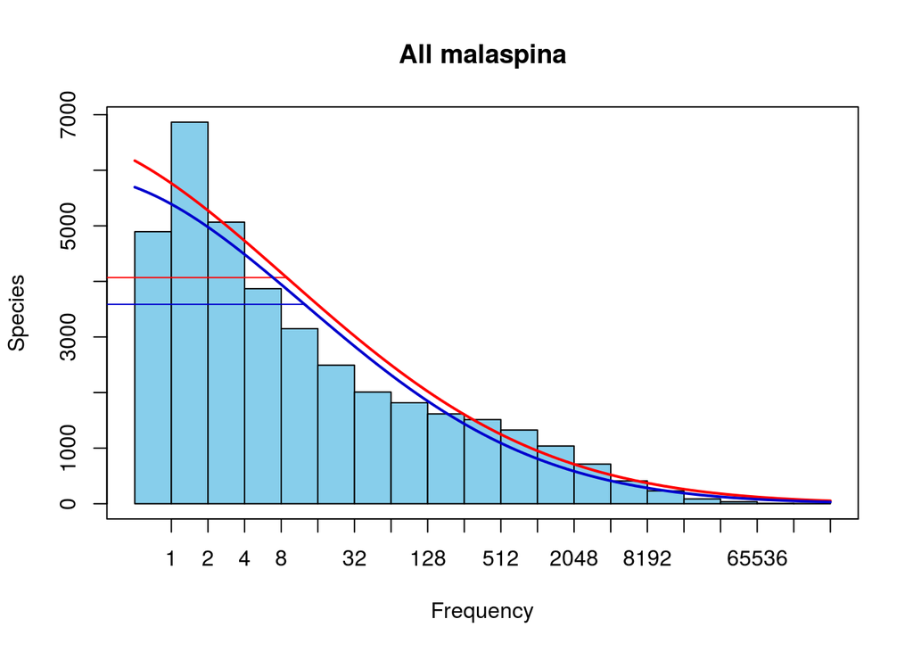

```
## Extrapolated     Observed       Veiled
##     94773.78     37142.00     57631.78
```

## 3.6) Beta diversity

### 3.6.1) Dissimilarity matrix using Bray-Curtis index:

The Bray-Curtis dissimilarity, constrained between 0 (minimum distance) and 1 (highest dissimilarity) allows us to quantify the differences between samples according to the composition and relative abundance of their OTUs. In our dataset, most of the samples pairs take dissimilarity values between 0.85 and 0.95, meaning that their composition is highly different.

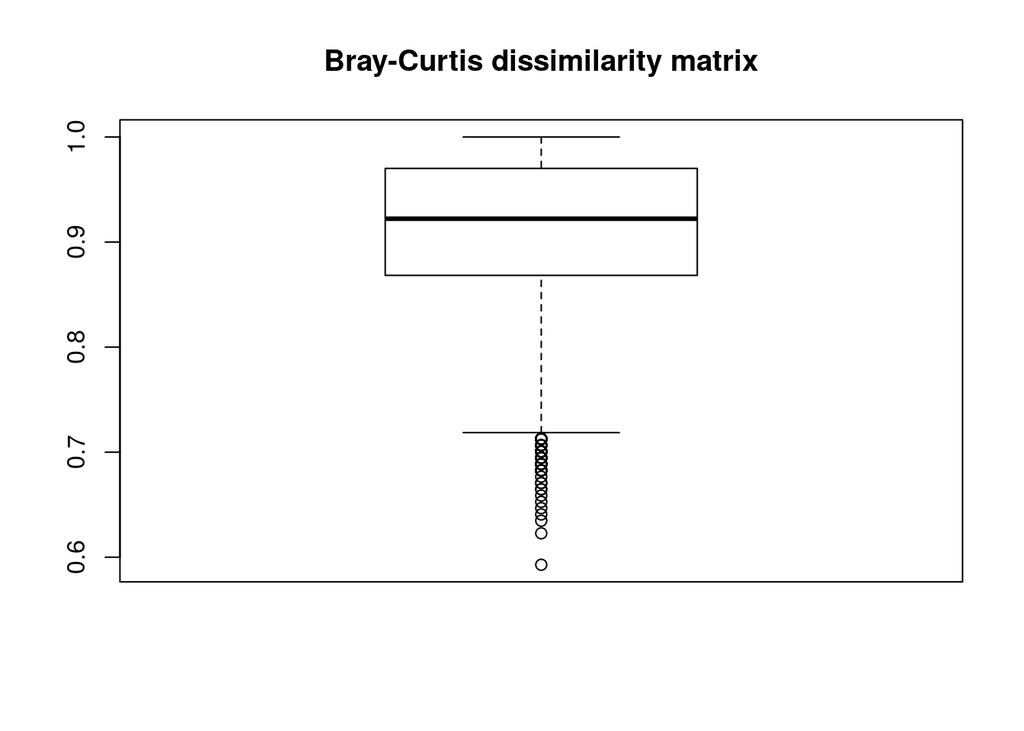

### 3.6.2) Hierarchical clustering

We do observe distinguished clusters; we’ll need to implement further analysis to determine if the observed groups are meaningful.

(To be done: add Longhurst provinces and sampling depth information)

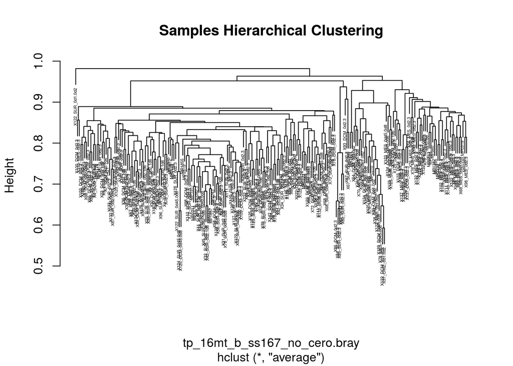

### 3.6.3) Non-metric multidimensional scaling

In general terms, we can distinguish a big cluster in the middle of the chart and two weak groups clustering in the middle-right side of the edge.

The stress parameter takes a value below 0.3, meaning that the plot is valid.

```
##
## Call:
## monoMDS(dist = tp_16mt_b_ss167_no_cero.bray)
##
## Non-metric Multidimensional Scaling
##
## 220 points, dissimilarity 'bray', call 'vegdist(x = tp_16mt_b_ss167_no_cero, method = "bray")'
##
## Dimensions: 2
## Stress:     0.1720353
## Stress type 1, weak ties
## Scores scaled to unit root mean square, rotated to principal components
## Stopped after 115 iterations: Stress nearly unchanged (ratio > sratmax)
```

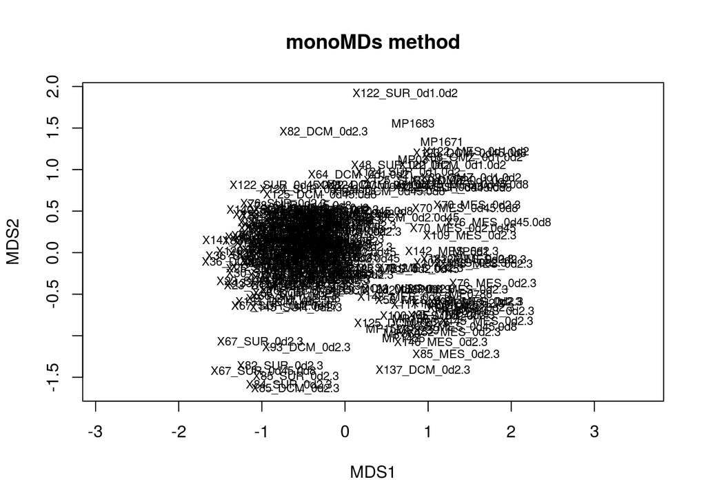

When implementing a most robut function for computing NMDS plots, the result is quiet the same:

```
## ... procrustes: rmse 0.0003597126  max resid 0.003699006
## *** Solution reached
```

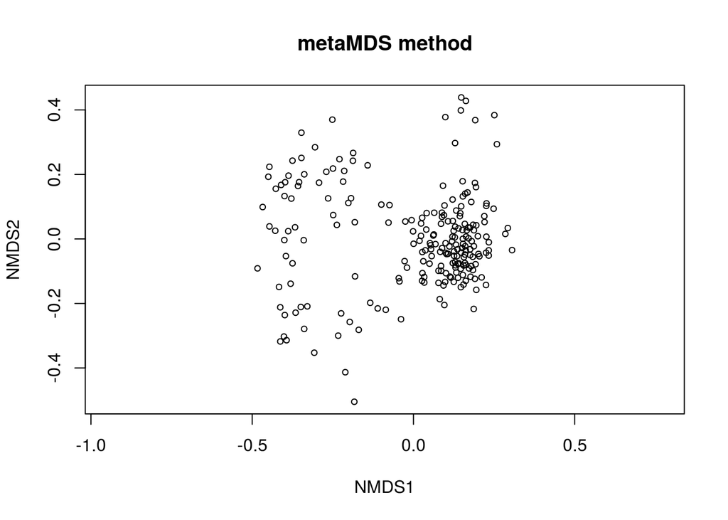

# 4) Geographical analysis

Working datasets:

1. Community matrix: tp_16mt_b_ss167_no_cero

```r
dim(tp_16mt_b_ss167_no_cero)
```

```
## [1]  220 6416
```

```r
tp_16mt_b_ss167_no_cero[1:5, 1:5]
```

```
##        OTU_1 OTU_2 OTU_3 OTU_4 OTU_5
## MP0310     0     0     0     0     0
## MP0311     0     0     0     0     0
## MP0319     0     0     0     0     0
## MP0321     0     0     0     0     0
## MP0323     0     0     0     0     0
```

```r
tp_16mt_b_ss167_no_cero.bray<-as.matrix(tp_16mt_b_ss167_no_cero.bray)
```

3. Stations distances in km: geo_distances_TP_16S_b_ss167

```r
dim(geo_distances_TP_16S_b_ss167)
```

```
## [1] 220 220
```

Communities quickly change their composition across geographical distances:

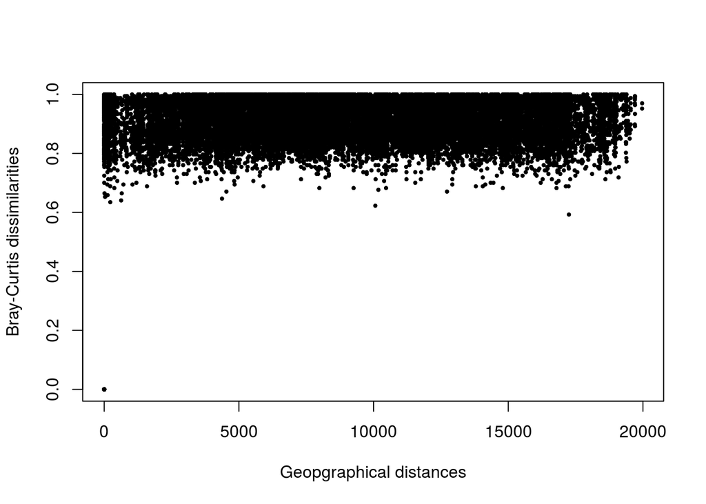

```r
plot(geo_distances_TP_16S_b_ss167, tp_16mt_b_ss167_no_cero.bray, pch=19, cex=0.4, xlab="Geopgraphical distances", ylab="Bray-Curtis dissimilarities")
```

## 4.1) Mantel correlograms

The Mantel Test statistic is significant, but it is so low, meaning that the correlation between samples composition and geographical distance is very weak.

```r
mantel(geo_distances_TP_16S_b_ss167, tp_16mt_b_ss167_no_cero.bray)
```

```
##
## Mantel statistic based on Pearson's product-moment correlation
##
## Call:
## mantel(xdis = geo_distances_TP_16S_b_ss167, ydis = tp_16mt_b_ss167_no_cero.bray)
##
## Mantel statistic r: 0.02418
##       Significance: 0.045
##
## Upper quantiles of permutations (null model):
##    90%    95%  97.5%    99%
## 0.0187 0.0235 0.0279 0.0319
## Permutation: free
## Number of permutations: 999
```

Maximum distance between samples:

```
## [1] 19969.22
```

Minimum distance between samples:

```
## [1] 0
```

Correlograms:

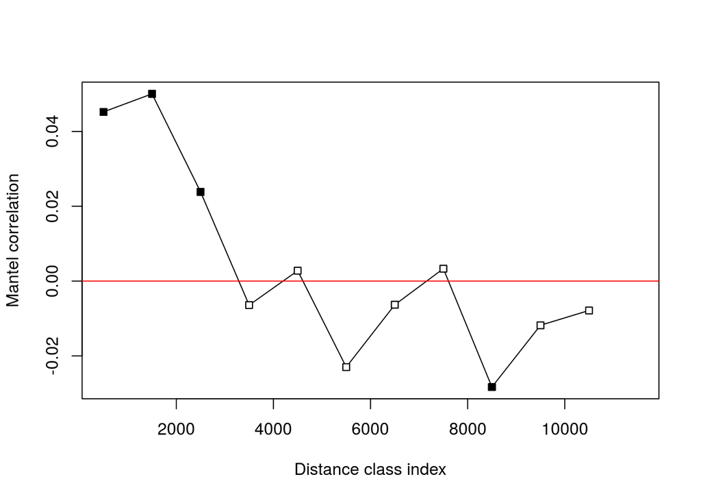

```r
TP_16S_b_ss167_mantel_correl_by_1000km<-mantel.correlog(tp_16mt_b_ss167_no_cero.bray, D.geo=geo_distances_TP_16S_b_ss167, break.pts=seq(0,20000, by=1000))
plot(TP_16S_b_ss167_mantel_correl_by_1000km)
```

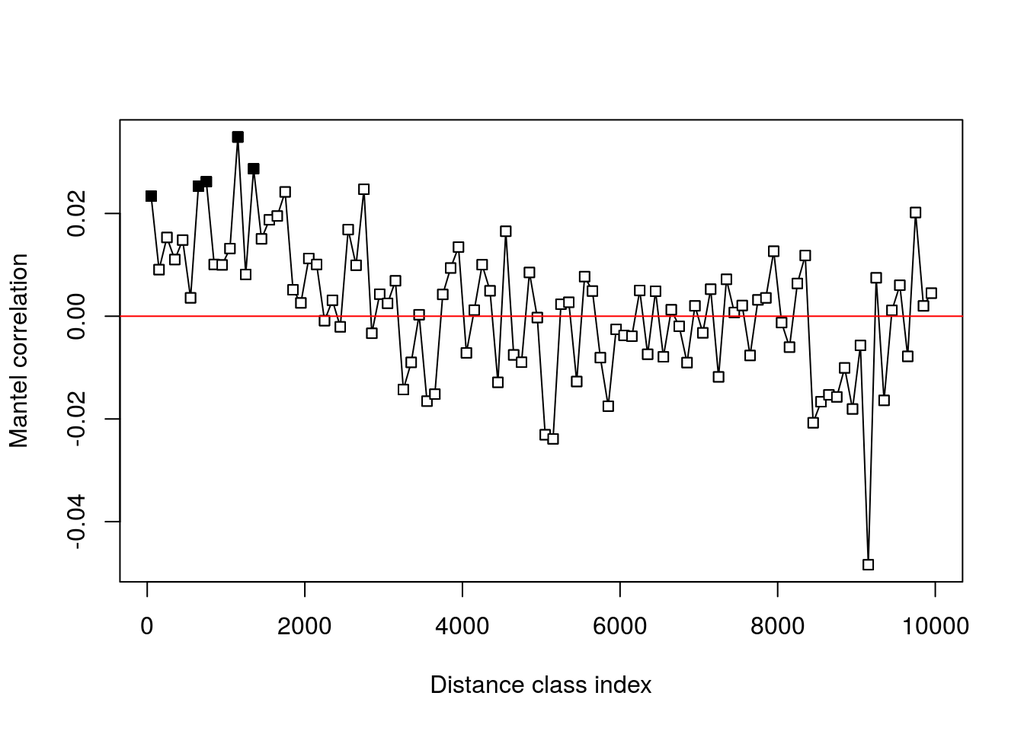

```r
TP_16S_b_ss167_mantel_correl_by_100km<-mantel.correlog(tp_16mt_b_ss167_no_cero.bray, D.geo=geo_distances_TP_16S_b_ss167, break.pts=seq(0,20000, by=100))
plot(TP_16S_b_ss167_mantel_correl_by_100km)
```

# 5) Abundance & occurence

In the following plot, we can appreciate the OTUs distribution according to their percentage of occurence and relative abundance. The blue line restricts regionally abundant OTUs (> 0.1%).

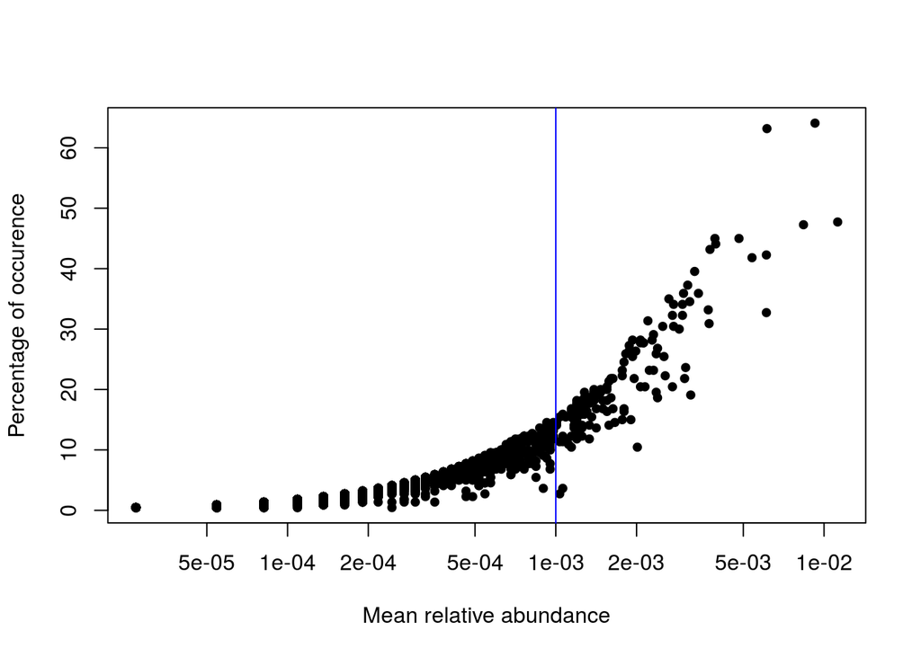

Regionally abundant OTUs (relative abundance over 0.1%):

```
##           mean_rabund perc_occur
## OTU_3009  0.011241154  47.727273
## OTU_321   0.009254219  64.090909
## OTU_2241  0.008383234  47.272727
## OTU_1499  0.006124115  63.181818
## OTU_2660  0.006096897  42.272727
## OTU_181   0.006096897  32.727273
## OTU_836   0.005389222  41.818182
## OTU_5223  0.004817637  45.000000
## OTU_145   0.003946652  44.090909
## OTU_856   0.003919434  45.000000
## OTU_4948  0.003756124  43.181818
## OTU_2955  0.003728906  30.909091
## OTU_2738  0.003701688  33.181818
## OTU_5093  0.003402286  35.909091
## OTU_1519  0.003293413  39.545455
## OTU_6009  0.003184540  19.090909
## OTU_1287  0.003157322  34.545455
## OTU_362   0.003102885  37.272727
## OTU_395   0.003048449  23.636364
## OTU_93    0.003021230  21.818182
## OTU_5148  0.002994012  35.909091
## OTU_461   0.002966794  34.090909
## OTU_3059  0.002966794  32.272727
## OTU_5420  0.002885139  30.000000
## OTU_4584  0.002749047  34.090909
## OTU_5701  0.002749047  30.454545
## OTU_4935  0.002721829  32.272727
## OTU_86    0.002721829  20.454545
## OTU_1839  0.002640174  35.000000
## OTU_5172  0.002558519  22.272727
## OTU_5132  0.002531301  25.454545
## OTU_402   0.002504083  30.454545
## OTU_5295  0.002395210  26.818182
## OTU_416   0.002395210  18.636364
## OTU_5490  0.002367991  25.909091
## OTU_2449  0.002367991  19.545455
## OTU_3092  0.002313555  29.090909
## OTU_5338  0.002313555  23.181818
## OTU_5263  0.002286336  28.181818
```

[output cut: 83 more lines]

```
## OTU_28    0.001143168  12.272727
## OTU_5166  0.001143168  10.454545
## OTU_5021  0.001115950  10.909091
## OTU_1118  0.001088732  15.454545
## OTU_235   0.001088732  11.818182
## OTU_382   0.001061513  15.909091
## OTU_1618  0.001061513  12.272727
## OTU_55    0.001061513  11.818182
## OTU_12    0.001061513  11.363636
## OTU_2281  0.001061513   3.636364
## OTU_4733  0.001034295  15.454545
## OTU_7421  0.001034295  11.363636
## OTU_3673  0.001034295   2.727273
## OTU_1569  0.001007077  14.545455
## OTU_5256  0.001007077  14.090909
```

```r
dim(tp_16mt_b_ss167_abundant_sorted)
```

```
## [1] 137   2
```

Proportion of regionally abundant OTUs (%):

```
## [1] 2.135287
```

Cosmopolitan OTUs (abundance over 0.1% and occurence in more than 80% of samples):

```
## [1] mean_rabund perc_occur
## <0 rows> (or 0-length row.names)
```

```r
dim(tp_16mt_b_ss167_cosmop_sorted)
```

```
## [1] 0 2
```

Proportion of cosmopolitan OTUs (%):

```
## [1] 0
```

Number and proportion (%) of rare OTUs:

```r
dim(tp_16mt_b_ss167_rabund_percoccur[tp_16mt_b_ss167_rabund_percoccur$mean_rabund < 0.00001 & tp_16mt_b_ss167_rabund_percoccur$mean_rabund >0,])
```

```
## [1] 0 2
```

```
## [1] 0
```

We can’t identify any instance of cosmopolitan or rare OTUs (!).